# Applications of Inference Frameworks

## Readings

Optional:

- Quick Bayesian introduction: http://andrewgelman.com/2016/12/13/bayesian-statistics-whats/

## Frameworks for inference

1. Analytical
2. Maximum likelihood
3. Resampling
4. Bayesian

## [Flying snake](https://www.youtube.com/playlist?list=PL1qTT-Q9lkEaw8eiGJOKOQjcYPIYYfvkL)

[video not shown]

## [Flying snake](https://www.youtube.com/playlist?list=PL1qTT-Q9lkEaw8eiGJOKOQjcYPIYYfvkL)

[video not shown]

## Inferring a mean

Mean undulation rate for \(n = 8\) [gliding snakes](http://www.flyingsnake.org/):

```r
undulation_rate <- c(0.9, 1.2, 1.2, 1.3, 1.4, 1.4, 1.6, 2.0)
```

[figure not shown]

What is the mean undulation rate for this sample of flying snakes?

## Undulation rate

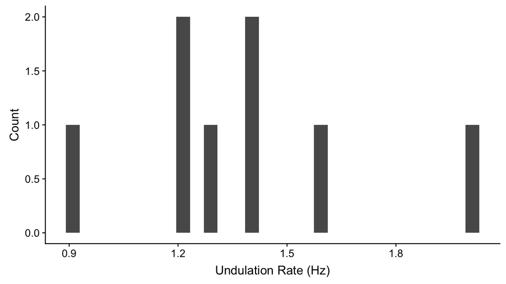

## Analytical inference of mean

Arithmetic mean:

\[\hat{Y} = \frac{\sum_{i=1}^{n}Y_i}{n}\]

\[mean~undulation~rate = \frac{\sum_{i=1}^{n}undulation~rate_i}{n}\]

## Analytical inference of mean

```r
sum(undulation_rate) / length(undulation_rate)
```

```
## [1] 1.375
```

```r
mean(undulation_rate)
```

```
## [1] 1.375
```

## Maximum likelihood inference of mean

Use `dnorm()` to calculate the relative likelihood of an observed value \(Y_i\) drawn from a [normal distribution](http://mathworld.wolfram.com/NormalDistribution.html) given a mean (\(\mu\)) and standard deviation (\(\sigma\)).

\[f\left(Y_i; \mu, \sigma\right) = \frac{1}{\sqrt{2\pi\sigma^{2}}} e^{\frac{-\left(Y_i-\mu\right)^{2}}{2\sigma^{2}}}\]

## Standard normal distribution

```r
dnorm(0, mean = 0, sd = 1)
```

```
## [1] 0.3989423
```

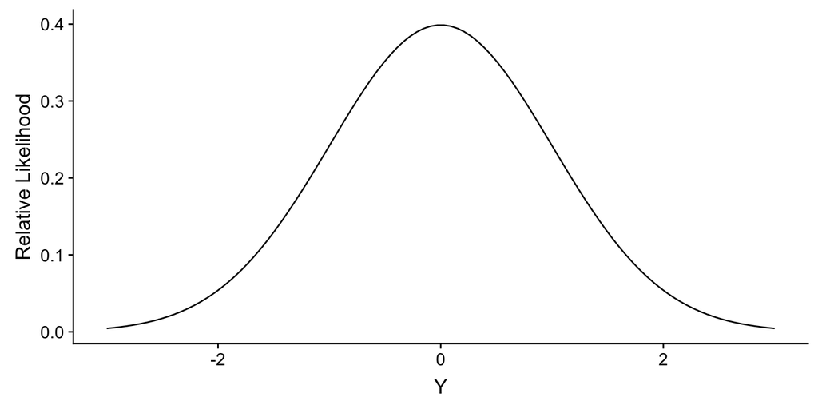

## Calculating a likelihood

*Hypothesizing that the population mean is 0 and the standard deviation is 1*, what is the likelihood of the observed values?

1. This is a model.
2. Calculate the relative likelihood of each observation
3. Model likelihood is the product of the individual likelihoods
4. log-likelihood is more tractable, so calculate that

## Model Likelihood (\(\mathcal{L}\))

For a set of observations (\(Y_i\)) and hypothesized parameters (\(\Theta\); i.e., mean and standard deviation) the model likelihood is the product of the observations’ individual likelihoods:

\[\mathcal{L}\left(\left\{ Y_{i}\right\} _{i=1}^{n};\Theta\right) = \prod_{i=1}^{n}\phi\left(Y_{i}; \Theta\right)\]

\[\log\left(\mathcal{L}\left(\left\{ Y_{i}\right\} _{i=1}^{n};\Theta\right)\right) = \sum_{i=1}^{n} \log\left(\phi\left(Y_{i};\Theta\right)\right)\]

## Calculating the log-likelihood for a single combination of \(\mu\) and \(\sigma\)

*Hypothesizing that the population mean is 0 and the standard deviation is 1*, what is the likelihood of the observed values?

Likelihood for the first observation (`undulation_rate[1]`):

```r
undulation_rate[1]
```

```
## [1] 0.9
```

```r
dnorm(undulation_rate[1], mean = 0, sd = 1)
```

```
## [1] 0.2660852
```

## Calculating the log-likelihood for a single combination of \(\mu\) and \(\sigma\)

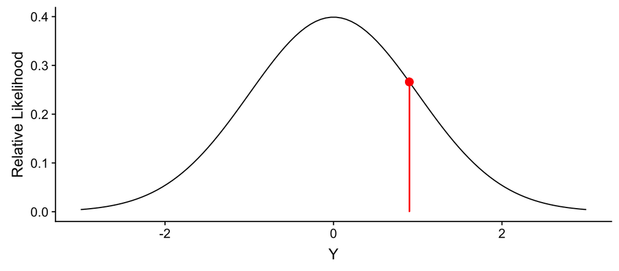

This is only the likelihood for *one* observation. We need the likelihoods for all 8 undulation rates to get a model likelihood.

## Calculating the log-likelihood for a single combination of \(\mu\) and \(\sigma\)

Vector of likelihoods for all values in `undulation_rate` given `mu = 0` and `sigma = 1`:

```r
(rel_liks <- dnorm(undulation_rate, mean = 0, sd = 1))
```

```
## [1] 0.26608525 0.19418605 0.19418605 0.17136859 0.14972747 0.14972747
## [7] 0.11092083 0.05399097
```

## Calculating the log-likelihood for a single combination of \(\mu\) and \(\sigma\)

Model likelihood is the product of those likelihoods:

```r
(lik <- prod(rel_liks))
```

```
## [1] 2.308476e-07
```

## Likelihood to log-likelihood

```r
log(lik)
```

```
## [1] -15.28151
```

Rather than logging the product, we can sum the log-likelihoods:

```r
sum(log(rel_liks))
```

```
## [1] -15.28151
```

For a model in which the mean is 0 and standard deviation is 1, the model log-likelihood is -15.28.

## Higher likelihood

Is there another combination of \(\mu\) and \(\sigma\) that gives a higher likelihood (= larger log-likelihood)?

Try \(\mu = 1\) and \(\sigma = 1\):

```r
sum(log(dnorm(undulation_rate, mean = 1, sd = 1)))
```

```
## [1] -8.281508
```

This is an improvement over \(\mu = 0\) and \(\sigma = 1\).

## Calculating the log-likelihood for a *range* of \(\mu\) and \(\sigma\)

Find the combination of \(\mu\) and \(\sigma\) that maximizes the log-likelihood of the model for the mean and standard deviation of undulation rates.

Ranges of possible values:

1. Mean (\(\mu\)): \(-\infty < \mu < \infty\)
2. Standard deviation (\(\sigma\)): \(0 < \sigma < \infty\)

## Grid approximation

For combinations of \(\mu\) and \(\sigma\), calculate the model likelihood. Pick the largest log-likelihood as the maximum likelihood estimates.

Set up the grid:

```r
n <- 100 # How fine is the grid
mus <- seq(0.1, 5, length = n) # Vector of mu
sigmas <- seq(0.1, 2, length = n) # Vector of sigma

grid_mu_sigma <- mesh(mus, sigmas) # Generate grid

# To hold the output
grid_approx <- tibble(
  mu = as.numeric(grid_mu_sigma$x),
  sigma = as.numeric(grid_mu_sigma$y),
  log_lik = rep(NA, length = n ^ 2)
)
```

```r
grid_approx
```

```
## # A tibble: 10,000 x 3
##       mu sigma log_lik
##    <dbl> <dbl> <lgl>
##  1 0.1     0.1 NA
##  2 0.149   0.1 NA
##  3 0.199   0.1 NA
##  4 0.248   0.1 NA
##  5 0.298   0.1 NA
##  6 0.347   0.1 NA
##  7 0.397   0.1 NA
##  8 0.446   0.1 NA
##  9 0.496   0.1 NA
## 10 0.545   0.1 NA
## # … with 9,990 more rows
```

## Grid approximation

```r
for (i in 1:nrow(grid_approx)) {
  grid_approx[i, "log_lik"] <-
    sum(log(dnorm(undulation_rate,
                  mean = grid_approx$mu[i],
                  sd = grid_approx$sigma[i])))
}
```

- Iterate through the rows (\(i\)) of `grid_approx`
- For each row, assign the model log-likelihood calculated for that `mu` and `sigma` to `log_lik`

```r
head(grid_approx)
```

```
## # A tibble: 6 x 3
##      mu sigma log_lik
##   <dbl> <dbl>   <dbl>
## 1 0.1     0.1   -676.
## 2 0.149   0.1   -626.
## 3 0.199   0.1   -579.
## 4 0.248   0.1   -533.
## 5 0.298   0.1   -490.
## 6 0.347   0.1   -448.
```

This approach is coarse, time consuming, and not feasible for fine grids or many parameters.

- For a 100 X 100 grid, there are 10,000 calculations.
- If there were 3 parameters, there would be 1,000,000.

## Grid approximation

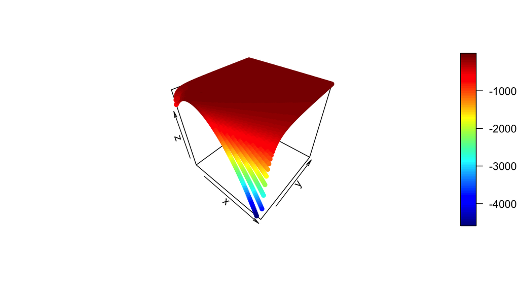

## Grid approximation

On this grid, the maximum likelihood estimate of \(\mu\) is:

```r
grid_approx[which.max(grid_approx$log_lik), ]
```

```
##            mu     sigma   log_lik
## 1127 1.386869 0.3111111 -1.813363
```

The analytical estimate is:

```r
mean(undulation_rate)
```

```
## [1] 1.375
```

## Maximum likelihood via optimization

Search for the most likely values of \(\mu\) and \(\sigma\).

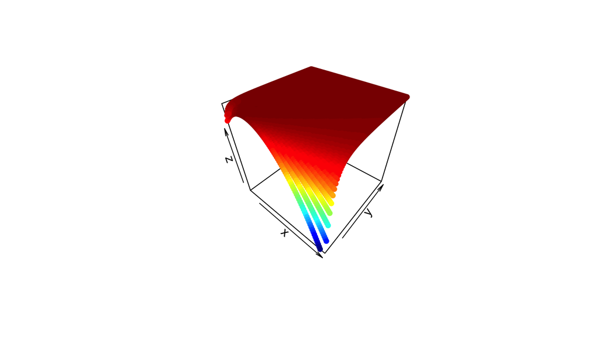

## Maximum likelihood via optimization

Define a function that takes a vector of values to optimize `x` (\(\mu\) and \(\sigma\)) as well as a set of data `Y` and returns the log-likelihood:

```r
log_lik <- function(x, Y){
  liks <- dnorm(Y, mean = x[1], sd = x[2])
  return(sum(log(liks)))
}
```

We can now simultaneously optimize \(\mu\) and \(\sigma\), maximizing the log-likelihood.

## Maximum likelihood via optimization

`reltol` says to stop when the improvement is \(<10^{-100}\).

```r
optim(c(0.1, 0.1), # Start at 0.1, 0.1
      log_lik,
      Y = undulation_rate,
      control = list(fnscale = -1,
                     reltol = 10^-100))
```

```
## $par
## [1] 1.3750000 0.3031089
##
## $value
## [1] -1.802203
##
## $counts
## function gradient
##      219       NA
##
## $convergence
## [1] 0
##
## $message
## NULL
```

## Maximum likelihood via optimization

`glm()` fits generalized linear modules via optimization:

```r
fm <- glm(undulation_rate ~ 1) # Estimate a mean only
coef(fm)
```

```
## (Intercept)
##       1.375
```

```r
logLik(fm)
```

```
## 'log Lik.' -1.802203 (df=2)
```

**For a small enough tolerance, the maximum likelihood estimate equals the analytical estimate.**

## Resampling inference of the mean

```r
set.seed(36428)
reps <- 100000
resampled_mean <- numeric(length = reps)

for (i in 1:reps) {
  resampled_mean[i] <- mean(sample(undulation_rate,
                                   replace = TRUE))
}
```

## Resampling inference of the mean

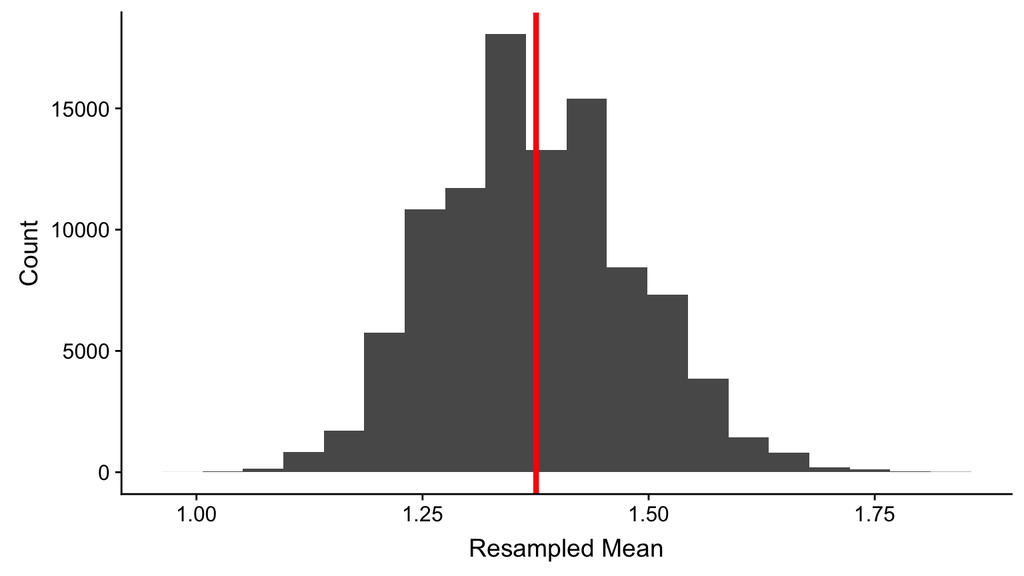

## Resampling inference of the mean

```r
mean(undulation_rate)
```

```
## [1] 1.375
```

```r
mean(resampled_mean)
```

```
## [1] 1.375541
```

**Given enough iterations, the resampled mean equals the analytical mean (and equals the ML mean).**

## Bayesian vs. ML inference

Maximum likelihood inference:

- Probability of the data, given the parameter estimate
- Parameters are fixed; data varies.
- No prior possible

Bayesian inference:

- Probability of the parameters, given the data
- Data are fixed; parameters vary.
- Prior required

## Bayesian inference of the mean

Ranges of possible maximum likelihood values:

1. \(\mu\): \(-\infty < \mu < \infty\)
2. \(\sigma\): \(0 < \sigma < \infty\)

Drawbacks:

1. \(\mu\) can’t be negative (no negative undulation rates) and probably isn’t a large number
2. \(\sigma\) is also probably not huge either

Can we do better? Yes, Bayesian priors.

## Prior for the mean

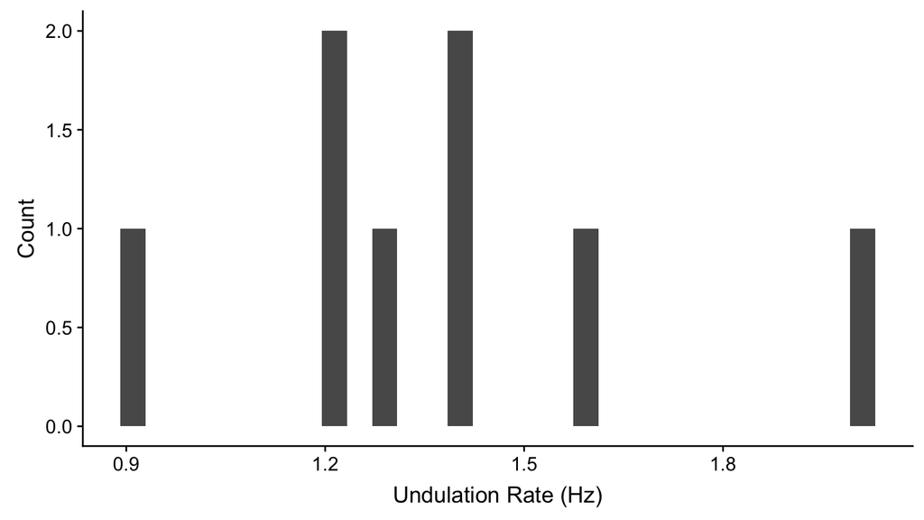

## Prior for the mean

Cauchy distribution (location = 0, scale = 5)

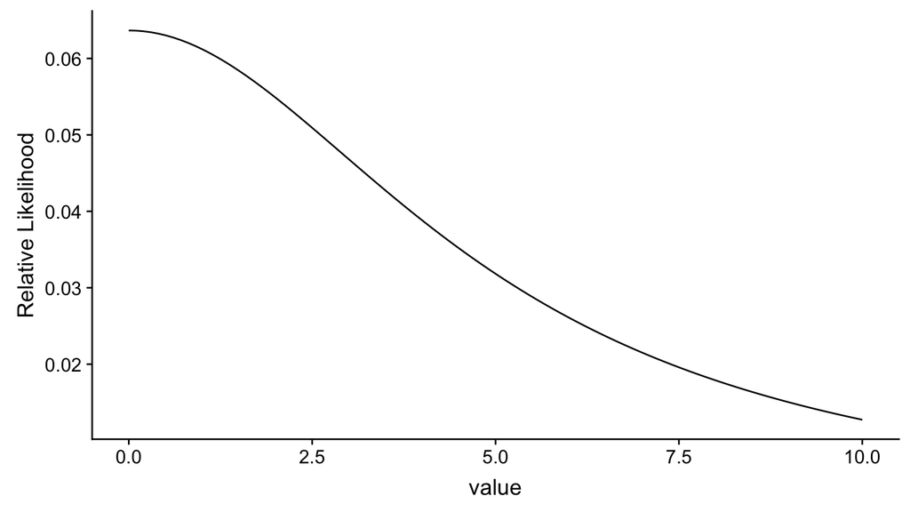

## Bayesian model

[stan](http://mc-stan.org/) code:

```r
model <- "
  data{
    int<lower=1> N;
    real undulation_rate[N];
  }
  parameters{
    real<lower=0> mu;
    real<lower=0> sigma;
  }
  model{
    sigma ~ cauchy(0, 5);
    mu ~ cauchy(0, 5);
    undulation_rate ~ normal(mu, sigma);
  }
"
```

## Sample the Bayesian model

```r
fm_priors <- stan(
  model_code = model,
  data = list(undulation_rate = undulation_rate,
              N = length(undulation_rate)),
  iter = 10^4,
  warmup = 10^3)
```

## Inspecting the samples

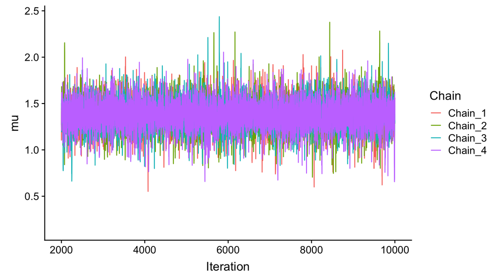

## Summarizing the results

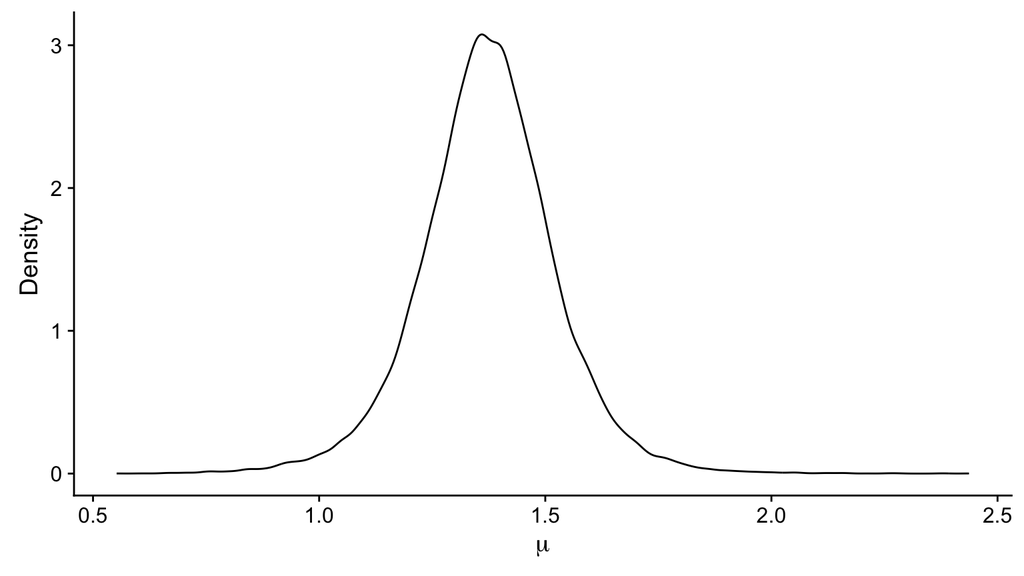

## Summarizing the results

```
## Inference for Stan model: 442a2122841096b226ccbdd3d2b4e13e.
## 4 chains, each with iter=10000; warmup=1000; thin=1;
## post-warmup draws per chain=9000, total post-warmup draws=36000.
##
##        mean se_mean    sd  2.5%   25%   50%   75% 97.5% n_eff Rhat
## mu    1.373   0.001 0.152 1.063 1.284 1.373 1.463 1.676 13464    1
## sigma 0.403   0.001 0.145 0.225 0.306 0.371 0.462 0.770 12451    1
## lp__  3.454   0.012 1.172 0.258 3.000 3.817 4.296 4.603  9664    1
##
## Samples were drawn using NUTS(diag_e) at Sat Feb  2 18:20:07 2019.
## For each parameter, n_eff is a crude measure of effective sample size,
## and Rhat is the potential scale reduction factor on split chains (at
## convergence, Rhat=1).
```

Lower mean than the analytical or ML estimate (1.375) because the prior places more probability on lower values.

## Quiz 04-3

Complete quiz 04-3.

This is the final lecture for this week.